# 104.2. Explore the Butler repository

For the Rubin Science Platform at data.lsst.cloud.  
Data Release: [Data Preview 1](https://dp1.lsst.io)  
Container Size: large  
LSST Science Pipelines version: r29.2.0  
Last verified to run: 2025-09-02  
Repository: github.com/lsst/tutorial-notebooks

**Learning objective:** How to explore Butler collections, datasets, dimensions, and schema.

**LSST data products:** Butler dimension records (metadata)

**Packages:** `lsst.daf.butler`

**Credit:** Originally developed by the Rubin Community Science team. Please consider acknowledging them if this notebook is used for the preparation of journal articles, software releases, or other notebooks.

**Get Support:** Everyone is encouraged to ask questions or raise issues in the [Support Category](https://community.lsst.org/c/support) of the Rubin Community Forum. Rubin staff will respond to all questions posted there.

## 1. Introduction

The Butler is LSST Science Pipelines middleware for managing, reading, and writing datasets.

As the interface between the pipelines and the data, it is often referred to as "middleware".

Butler-related documentation:

- [pipelines middleware Frequently Asked Questions](https://pipelines.lsst.io/middleware/index.html)
- [butler python module documentation](https://pipelines.lsst.io/modules/lsst.daf.butler/index.html)

**This tutorial** demonstrates how to explore the Butler: how to discover what kind of data is accessible and its schema, which dimensions to use to query and retrieve datasets, and how to visualize metadata.

**Related tutorials:** The first 100-level Butler tutorial in this series provides a basic introduction to how to use the Butler; later tutorials in this series demonstrate advanced Butler queries.

### 1.1. Import packages

Also import `numpy` and modules from `matplotlib`.

```python
from lsst.daf.butler import Butler
import lsst.sphgeom as sphgeom
import lsst.geom as geom
from lsst.utils.plotting import (get_multiband_plot_colors,
                                 get_multiband_plot_symbols,
                                 get_multiband_plot_linestyles)

import numpy as np
import matplotlib.pyplot as plt
import matplotlib.lines as mlines
from matplotlib.patches import Polygon
```

### 1.2. Define parameters and functions

Create an instance of the Butler with the repository and collection for DP1, and assert that it exists.

```python
butler = Butler("dp1", collections="LSSTComCam/DP1")
assert butler is not None
```

```python
plt.style.use('seaborn-v0_8-colorblind')
prop_cycle = plt.rcParams['axes.prop_cycle']
colors = prop_cycle.by_key()['color']
```

Define the standard colors and linestyles to represent LSST filters.

```python
filter_names = ['u', 'g', 'r', 'i', 'z', 'y']
filter_colors = get_multiband_plot_colors()
filter_symbols = get_multiband_plot_symbols()
filter_linestyles = get_multiband_plot_linestyles()
```

## 2. Explore the Butler

Learn how to explore the datasets available via the Butler, and their properties.

### 2.1. Repositories and collections

Repositories are defined by data release (e.g., DP0.2, DP1).

In Section 1.2 above, the DP1 repository (`"dp1"`) and collection (`"LSSTComCam/DP1"`) were defined when the Butler was instantiated with `butler = Butler("dp1", collections="LSSTComCam/DP1")`. Any queries for data run with the Butler would look only in that collection.

Print the information about collection `LSSTComCam/DP1`.

```python
butler.collections.query_info("LSSTComCam/DP1")
```

```
[CollectionInfo(name='LSSTComCam/DP1', type=<CollectionType.CHAINED: 3>, doc='', children=('LSSTComCam/runs/DRP/DP1/DM-51335', 'LSSTComCam/runs/DRP/DP1/v29_0_0/DM-50260'), parents=None, dataset_types=None)]
```

It is also possible to explore what other repositories and collections exist.

List all available repositories.

```python
butler.get_known_repos()
```

```
{'dp02', 'dp02-remote', 'dp1'}
```

Collections are groups of self-consistent datasets, e.g., the outputs of a processing run that uses a single set of calibrations.

Store a list of all collection names in `all_collections`.

```python
all_collections = butler.collections.query("*")
```

Option to print all collections.

```python
# for collection in all_collections:
#     print(collection)
```

```python
del all_collections
```

### 2.2. Dataset types

Commonly-used image dataset types:

- `deep_coadd`
- `visit_image`

Commonly-used catalog dataset types:

- `object`
- `source`

Uncomment and execute the following cell to print a very long list of every possible dataset type.

> **Warning:** The `butler.registry` module used below is being deprecated, but the functionality to `queryDatasetTypes` will be made available elsewhere.

> **Warning:** The `queryDatasetTypes` function returns every type that has ever been named or defined, and is *not a list of dataset types that are currently populated and available*.

```python
# butler.registry.queryDatasetTypes()
```

Option to print only the dataset types with `coadd` in their name.

```python
# butler.registry.queryDatasetTypes('*coadd*')
```

Option to print the dataset types with `map` in their name.

```python
# butler.registry.queryDatasetTypes('*map*')
```

Option to print the dataset types with `object` in their name.

```python
# butler.registry.queryDatasetTypes('*object*')
```

### 2.3. Dimensions and elements

The dimensions and elements are the properties of a dataset type that can be constrained in a Butler query.

Commonly-used dimensions:

- `band`
- `tract`
- `patch`
- `visit`
- `detector`

Commonly-used element:

- `visit_detector_region`

Print the full lists of dimensions and elements.

```python
print(butler.dimensions.getStaticDimensions())
```

```
{band, healpix1, healpix2, healpix3, healpix4, healpix5, healpix6, healpix7, healpix8, healpix9, healpix10, healpix11, healpix12, healpix13, healpix14, healpix15, healpix16, healpix17, htm1, htm2, htm3, htm4, htm5, htm6, htm7, htm8, htm9, htm10, htm11, htm12, htm13, htm14, htm15, htm16, htm17, htm18…
```

```python
print(butler.dimensions.getStaticElements())
```

```
{band, healpix1, healpix2, healpix3, healpix4, healpix5, healpix6, healpix7, healpix8, healpix9, healpix10, healpix11, healpix12, healpix13, healpix14, healpix15, healpix16, healpix17, htm1, htm2, htm3, htm4, htm5, htm6, htm7, htm8, htm9, htm10, htm11, htm12, htm13, htm14, htm15, htm16, htm17, htm18…
```

Show that the dimensions for the `deep_coadd` dataset type are `band, skymap, tract, patch`, and that the returned format for images is `ExposureF`.

```python
butler.get_dataset_type('deep_coadd')
```

```
DatasetType('deep_coadd', {band, skymap, tract, patch}, ExposureF)
```

Print each dimension key using the `dimensions.data_coordinate_keys` attribute.

```python
dataset_type = butler.get_dataset_type('deep_coadd')
for dimension in dataset_type.dimensions.data_coordinate_keys:
    print(dimension)
```

```
band
skymap
tract
patch
```

Print all dimension keys for the `visit_image` dataset type.

```python
dataset_type = butler.get_dataset_type('visit_image')
for dimension in dataset_type.dimensions.data_coordinate_keys:
    print(dimension)
```

```
instrument
detector
visit
band
day_obs
physical_filter
```

#### 2.3.1. Required dimensions

Some dimensions are redundant, like `band` and `physical_filter`, or `day_obs` and `visit`. Print only the subset of required dimensions for the `visit_image` dataset type.

```python
dataset_type = butler.get_dataset_type('visit_image')
for dimension in dataset_type.dimensions.required:
    print(dimension)
```

```
instrument
detector
visit
```

```python
del dataset_type
```

### 2.4. Schema

The set of dimensions for a given dataset type have schema which define how a Butler query for a given dataset type can be constructed.

Print the schema for each dimension of the `deep_coadd` dataset type.

```python
dataset_type = butler.get_dataset_type('deep_coadd')
for dimension in dataset_type.dimensions.data_coordinate_keys:
    print('dimension = ', dimension)
    print(butler.dimensions[dimension].schema)
    print(' ')
```

```
dimension =  band
band:
  name: string

dimension =  skymap
skymap:
  name: string
  hash: hash
    A hash of the skymap's parameters.
  tract_max: int
    Maximum ID for tracts in this skymap, exclusive.
  patch_nx_max: int
    Number of patches in the x direction in each tract.
  patch_ny_max: int
    Number of patches in the y direction in each tract.

dimension =  tract
tract:
  skymap: string
  id: int
  region: region

dimension =  patch
patch:
  skymap: string
  tract: int
  id: int
  cell_x: int
    Which column this patch occupies in the tract's grid of patches.
  cell_y: int
    Which row this patch occupies in the tract's grid of patches.
  region: region
```

The output above shows, for example, that a query for `deep_coadd` images can be constrained by the `tract` and `patch` `id` values (unique integers), or with `region` (see example in Section 3.1).

Option to print the schema for each dimension of the `visit_image` dataset type.

```python
# dataset_type = butler.get_dataset_type('visit_image')
# for dimension in dataset_type.dimensions.data_coordinate_keys:
#     print('dimension = ', dimension)
#     print(butler.dimensions[dimension].schema)
#     print(' ')
```

Option to print the schema for the `object` table.

```python
# dataset_type = butler.get_dataset_type('object')
# for dimension in dataset_type.dimensions.data_coordinate_keys:
#     print('dimension = ', dimension)
#     print(butler.dimensions[dimension].schema)
#     print(' ')
```

### 2.5. Dimension records

Return all records for a given dimension in the collection (i.e., all unique instruments, bands, tracts, patches, visits, detectors).

Print all unique instruments in the collection, and see that DP1 contains only LSSTComCam data.

```python
butler.query_dimension_records('instrument')
```

```
[instrument.RecordClass(name='LSSTComCam', visit_max=7050123199999, visit_system=2, exposure_max=7050123199999, detector_max=1000, class_name='lsst.obs.lsst.LsstComCam')]
```

Print all unique bands (filters) in the collection, and see that the LSST filters *ugrizy* are all included.

```python
butler.query_dimension_records('band')
```

```
[band.RecordClass(name='r'),
 band.RecordClass(name='z'),
 band.RecordClass(name='y'),
 band.RecordClass(name='g'),
 band.RecordClass(name='i'),
 band.RecordClass(name='unknown'),
 band.RecordClass(name='u'),
 band.RecordClass(name='OG590'),
 band.RecordClass(name='white')]
```

Print the unique tracts in the DP1 collection, and see that there are only 31 because DP1 covers a relatively small area.

```python
all_tracts = butler.query_dimension_records('tract')
all_tract_ids = []
for tract in all_tracts:
    all_tract_ids.append(tract.id)
print('Number of DP1 tracts: ', len(all_tract_ids))
print(all_tract_ids)
del all_tracts, all_tract_ids
```

```
Number of DP1 tracts:  31
[453, 454, 531, 532, 2234, 2235, 2393, 2394, 4016, 4017, 4217, 4218, 4848, 4849, 5062, 5063, 5064, 5305, 5306, 5525, 5526, 7610, 7611, 7849, 7850, 10221, 10222, 10463, 10464, 10704, 10705]
```

Options to get all visit or all detector ids.

```python
# all_visits = butler.query_dimension_records('visit')
# all_visit_ids = []
# for visit in all_visits:
#     all_visit_ids.append(visit.id)
# print('Number of DP1 visits: ', len(all_visit_ids))
# del all_visits, all_visit_ids
```

```python
# all_detectors = butler.query_dimension_records('detector')
# all_detector_ids = []
# for detector in all_detectors:
#     all_detector_ids.append(detector.id)
# print('Number of DP1 detectors: ', len(all_detector_ids))
# print(all_detector_ids)
# del all_detectors, all_detector_ids
```

### 2.6. DataIds

The `dataId` is a dictionary in which the keys are dimensions, and the values uniquely identify a data product of a given dataset type.

In Section 2.3., the dimensions of a `deep_coadd` were shown to be `band`, `skymap`, `tract`, and `patch`. The `dataId` for a unique `deep_coadd` image is a dictionary that contains the values for each dimension (key), such as:

`dataId = {"band": "r", "skymap": "lsst_cells_v1", "tract": 5063, "patch": 14}`

Option to print all unique `dataId` values for instrument, band, and tract. This returns similar lists as in Section 2.5 above.

```python
# butler.query_data_ids('instrument')
```

```python
# butler.query_data_ids('band')
```

Tracts are defined for a particular skymap.

```python
# butler.query_data_ids('tract')
```

### 2.7. Skymap, tract, and patch

The skymap defines the all-sky tesselation of tracts and patches for the deep coadd images.

Use the Butler's `get_dataset_type` function to show that the dimension for the `skyMap` dataset type is just `skymap`, and that the returned format for the skymap is `SkyMap`.

```python
butler.get_dataset_type("skyMap")
```

```
DatasetType('skyMap', {skymap}, SkyMap)
```

Show the schema for the `skymap`.

```python
dataset_type = butler.get_dataset_type('skyMap')
for dimension in dataset_type.dimensions.data_coordinate_keys:
    print('dimension = ', dimension)
    print(butler.dimensions[dimension].schema)
    print(' ')
```

```
dimension =  skymap
skymap:
  name: string
  hash: hash
    A hash of the skymap's parameters.
  tract_max: int
    Maximum ID for tracts in this skymap, exclusive.
  patch_nx_max: int
    Number of patches in the x direction in each tract.
  patch_ny_max: int
    Number of patches in the y direction in each tract.
```

Return all `skymap` records for DP1: there is only one, `lsst_cells_v1`.

```python
butler.query_dimension_records('skymap')
```

```
[skymap.RecordClass(name='lsst_cells_v1', hash=b'\xe2snA$M\xf0\x0b\xbd\xb9:\xec\xac\n\xe4\xb2\xd1\x9d\xda\x91', tract_max=18938, patch_nx_max=10, patch_ny_max=10)]
```

Retrieve the `skymap` from the butler.

```python
skymap = butler.get("skyMap", skymap="lsst_cells_v1")
```

Option to print the `help` for `skymap`.

```python
# help(skymap)
```

Print all methods available for the returned `skymap`.

```python
for tmp in dir(skymap):
    if tmp[0] != '_':
        print(tmp)
```

```
ConfigClass
SKYMAP_DATASET_TYPE_NAME
SKYMAP_RUN_COLLECTION_NAME
config
findAllTracts
findClosestTractPatchList
findTract
findTractIdArray
findTractPatchList
generateTract
getRaDecRange
getRingIndices
getSha1
logSkyMapInfo
register
updateSha1
```

A few of these methods are particularly useful.

Print the minimum and maximum RA and Dec covered by a given tract.

```python
tract = skymap.getRaDecRange(5063)
tract
```

```
(Angle(52.258064516129039, degrees),
 Angle(53.917050691244235, degrees),
 Angle(-28.264462809917354, degrees),
 Angle(-26.776859504132226, degrees))
```

Print the tract and patch for RA, Dec = $53.076, -28.110$ deg.

```python
ra = 53.076
dec = -28.110
point = geom.SpherePoint(ra*geom.degrees, dec*geom.degrees)
tract = skymap.findTract(point)
patch = tract.findPatch(point)
print(tract.tract_id, patch.getSequentialIndex())
del ra, dec, tract, patch
```

```
5063 15
```

Tracts and patches overlap. Get all overlapping tracts and patches.

```python
tplist = skymap.findTractPatchList([point])
```

Display the list of tracts and patches, `tplist`, and see that one tract and two patches overlap the coordinates.

```python
tplist
```

```
[(TractInfo(id=5063, ctrCoord=[0.5326332312997893, 0.7090801040994212, -0.46206844394039615]),
  (PatchInfo(index=Index2D(x=4, y=1), innerBBox=(minimum=(12000, 3000), maximum=(14999, 5999)), outerBBox=(minimum=(11800, 2800), maximum=(15199, 6199)), cellInnerDimensions=(150, 150), cellBorder=50, numCellsPerPatchInner=22),
   PatchInfo(index=Index2D(x=5, y=1), innerBBox=(minimum=(15000, 3000), maximum=(17999, 5999)), outerBBox=(minimum=(14800, 2800), maximum=(18199, 6199)), cellInnerDimensions=(150, 150), cellBorder=50, numCellsPerPatchInner=22)))]
```

Print the tract and two patch ids for all that overlap the provided coordinates.

```python
for tmp in tplist:
    tract = tmp[0]
    patches = tmp[1]
    for patch in patches:
        print(tract.getId(), patch.getSequentialIndex())
```

```
5063 14
5063 15
```

```python
del point, tplist, skymap
```

## 3. Visualize Butler metadata

### 3.1. Tract and patch boundaries

Use the `skymap` and `deep_coadd` metadata to draw tract and patch boundaries.

Retrieve all the `tract` and `patch` dimension records for all `tracts` and `patches` within 10 degrees of RA, Dec = $53.076, -28.110$ deg. Those coordinates are near the center of the Extended Chandra Deep Field South (ECDFS).

```python
region = sphgeom.Region.from_ivoa_pos("CIRCLE 53.076 -28.110 10.0")
tract_dimrecs = butler.query_dimension_records("tract",
                                               where="tract.region OVERLAPS :region",
                                               bind={"region": region})
patch_dimrecs = butler.query_dimension_records("patch",
                                               where="patch.region OVERLAPS :region",
                                               bind={"region": region})
print('Number of overlapping patches: ', len(patch_dimrecs))
```

```
Number of overlapping patches:  93
```

Define a color dictionary that assigns a color from the colortable to each tract.

```python
color_dict = {}
for r, rec in enumerate(tract_dimrecs):
    color_dict[rec.dataId['tract']] = colors[r]
print(color_dict)
```

```
{4848: '#0072B2', 4849: '#009E73', 5062: '#D55E00', 5063: '#CC79A7', 5064: '#F0E442'}
```

The patch dimension records returned from the Butler include the `region` as a `ConvexPolygon3D` with four vertices.

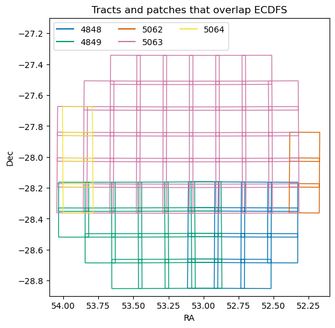

```python
fig, ax = plt.subplots(figsize=(6, 6))

for rec in patch_dimrecs:
    vertices = rec.region.getVertices()
    vertices_deg = []
    for vertex in vertices:
        vertices_deg.append([geom.SpherePoint(vertex).getRa().asDegrees(),
                             geom.SpherePoint(vertex).getDec().asDegrees()])
    polygon = Polygon(vertices_deg, closed=True, facecolor='None',
                      edgecolor=color_dict[rec.dataId['tract']])
    ax.add_patch(polygon)

ax.set_xlim(54.1, 52.1)
ax.set_ylim(-28.9, -27.1)
ax.set_xlabel('RA')
ax.set_ylabel('Dec')

handles = []
labels = []
for clr in color_dict:
    line = mlines.Line2D([], [], color=color_dict[clr], linestyle='-')
    handles.append(line)
    labels.append(clr)
plt.legend(loc='upper left', ncol=3, handles=handles, labels=labels)

plt.title('Tracts and patches that overlap ECDFS')
plt.show()
```

> **Figure 1:** The boundaries of the 93 patches from the five different tracts that overlap the ECDFS DP1 field.

```python
del region, tract_dimrecs, patch_dimrecs
```

### 3.2. Visit dates

Plot the cumulative histogram of the number of visits in the ECDFS field over time, by filter.

Define the search region as in Section 3.1, above.

```python
region = sphgeom.Region.from_ivoa_pos("CIRCLE 53.076 -28.110 10.0")
```

Set the bins of the plot to cover the ECDFS observation dates, plus a few days before and after.

```python
use_bins = np.arange(60660-60622, dtype='int') + 60622
```

For each filter, return all visit dimension records that overlap the region. Create an array of the start times, in MJD, from every visit's timespan. Plot the cumulative distribution of start time to see how observations accumulated for ECDFS, per filter.

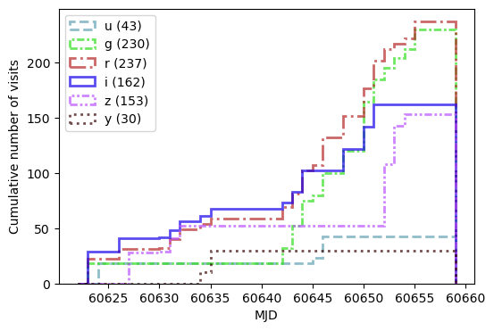

```python
fig = plt.figure(figsize=(6, 4))
for band in filter_names:
    visit_dimrecs = butler.query_dimension_records("visit",
                                                   where="band.name = :band AND \
                                                   visit.region OVERLAPS :region",
                                                   bind={"band": band, "region": region})
    temp = []
    for visit in visit_dimrecs:
        temp.append(visit.timespan.begin.mjd)
    all_visit_begin_mjd = np.sort(np.asarray(temp, dtype='float'))
    temp_label = band + ' (' + str(len(visit_dimrecs)) + ')'

    n, bins, patches = plt.hist(all_visit_begin_mjd, use_bins,
                                cumulative=True, histtype='step',
                                linewidth=2, alpha=0.7,
                                color=filter_colors[band],
                                label=temp_label)
    for patch in patches:
        patch.set_linestyle(filter_linestyles[band])

    del temp, all_visit_begin_mjd, temp_label, n, bins, patches

plt.legend(loc='upper left')
plt.xlabel('MJD')
plt.ylabel('Cumulative number of visits')
plt.show()
```

> **Figure 2:** The total, cumulative number of visits by Modified Julian Date (MJD) for each filter.

## Exercises for the learner

1. Print all dataset types with `source` in their name (Section 2.2).
2. Print each dimension key for dataset type `visit_image` (Section 2.3).
3. Show that seven patches from three tracts overlap coordinates RA, Dec = $53.84, -28.35$ deg.